# Growth rate dependence

John Favate

2021-07-29 11:39:40

```r
# Prevent printing of warnings and such in the HTML
knitr::opts_chunk$set(warning = FALSE, message = FALSE, fig.align = "center")
```

```r
library(tidyverse)
library(readxl)
library(parallel)
library(ggpubr)
library(broom)
library(patchwork)

mut.levels <- read_csv("../../data_frames/all_data.csv") %>%
  dplyr::select(line, mutator) %>%
  arrange(mutator, line) %>%
  unique() %>%
  pull(line)

mut.colors <- c("black", rep("black", 5), rep("firebrick3", 5))
```

We’re going to use data from this paper https://www.embopress.org/doi/full/10.15252/msb.20145108?download=true, specifically supplementary datasets 1 and 2, which were downloaded from that page because they were not playing nicely with wget. In the `../../data_frames/SF1-EcoMAC` folder are the expression data and the column names and rows in separate files. I’ll use them to make a single dataset.

```r
# these are the row names
rows <- read_tsv("../../data_frames/SF1-EcoMAC/numbering_assembly-tfs-enzymes-genes.txt", col_names = c("rn", "id", "gene"))

# these are the columns
column.names <- read_delim("../../data_frames/SF1-EcoMAC/numbering_arrays-compendium.txt", col_names = c("rn", "dataset"), delim = " ") %>%
  pull(dataset)

expr.data <- read_tsv("../../data_frames/SF1-EcoMAC/Ecoli-compendium-assembly-quantilenorm.txt", col_names = column.names) %>%
  cbind(rows) %>%
  select(id, gene, everything())

head(expr.data)
```

|  | id | gene | GSM311429 | GSM311430 | GSM311431 | GSM311432 | GSM311433 | GSM311434 | GSM311435 | GSM311436 | GSM311437 | GSM311438 | GSM311439 | GSM311440 | GSM311441 | GSM311442 | GSM311443 | GSM311444 | GSM311445 | GSM311446 | GSM311447 | GSM311448 | GSM311449 | GSM311450 | GSM311451 | GSM311452 | GSM311453 | GSM311454 | GSM311455 | … |
| --- | --- | --- | --- | --- | --- | --- | --- | --- | --- | --- | --- | --- | --- | --- | --- | --- | --- | --- | --- | --- | --- | --- | --- | --- | --- | --- | --- | --- | --- | --- |
| 1 | b0020 | nhaR | 8.98660 | 8.96573 | 9.16509 | 9.91827 | 9.31151 | 9.06478 | 8.82719 | 8.83624 | 9.79437 | 10.15640 | 8.91841 | 9.15758 | 9.31151 | 9.30762 | 8.84377 | 8.55237 | 8.87008 | 8.62564 | 9.54624 | 9.30997 | 8.63488 | 8.51612 | 9.07370 | 9.08255 | 8.52657 | 8.50713 | 9.02460 | … |
| 2 | b0034 | caiF | 7.67516 | 7.32882 | 9.23499 | 9.08551 | 7.82400 | 8.05827 | 9.11970 | 8.37412 | 7.30580 | 8.53955 | 8.85211 | 8.60526 | 7.39414 | 7.98649 | 6.58008 | 6.42124 | 7.51047 | 8.42283 | 7.28945 | 7.09718 | 8.31355 | 6.95008 | 6.87630 | 6.62456 | 8.08344 | 7.37407 | 6.58008 | … |
| 3 | b0064 | araC | 7.51420 | 7.72284 | 8.60211 | 8.60835 | 8.99406 | 9.28529 | 7.89005 | 8.51285 | 8.33009 | 8.17344 | 7.55864 | 7.89637 | 8.42283 | 8.38643 | 7.29414 | 7.01197 | 7.72426 | 7.80154 | 8.39427 | 8.62871 | 7.71853 | 6.51077 | 7.58729 | 7.78007 | 7.86254 | 7.59054 | 7.72284 | … |
| 4 | b0069 | sgrR | 9.36543 | 9.28220 | 9.25240 | 9.42441 | 9.64057 | 9.39643 | 9.41644 | 9.49830 | 9.54369 | 9.40689 | 9.48821 | 9.34818 | 9.34342 | 9.39158 | 8.36614 | 8.12625 | 8.32828 | 8.26429 | 8.17239 | 8.00939 | 8.48508 | 7.98007 | 8.46185 | 8.23070 | 8.48176 | 8.04523 | 8.39775 | … |
| 5 | b0076 | leuO | 7.72137 | 7.14853 | 7.54841 | 8.05535 | 7.46411 | 7.86897 | 7.68401 | 7.68866 | 7.72426 | 7.89637 | 7.70811 | 7.45182 | 7.72426 | 7.83697 | 6.59040 | 7.31727 | 7.36754 | 7.02094 | 7.67516 | 6.63398 | 7.95755 | 6.69269 | 6.76425 | 7.01197 | 6.58008 | 7.16898 | 6.61017 | … |
| 6 | b0080 | cra | 9.52766 | 9.30610 | 9.75456 | 10.74690 | 9.82313 | 9.57449 | 9.40286 | 10.25000 | 9.49492 | 9.19737 | 9.20262 | 9.15380 | 9.56333 | 9.70459 | 9.38757 | 9.06261 | 10.38250 | 10.74890 | 9.41802 | 9.72971 | 9.91299 | 10.17750 | 8.87904 | 9.29601 | 9.11230 | 9.12415 | 9.69898 | … |

The growth rates are in a separate excel sheet.

```r
g.rates <- read_xlsx("../../data_frames/SF1-EcoMAC/msb145108-sup-0005-datasets2.xlsx", sheet = 2) %>%
  arrange(`Column array (EcoMAC)`)

names(g.rates) <- str_replace_all(names(g.rates), " ", "_") %>%
  str_remove_all(., "\\(") %>%
  str_remove_all(., "\\)") %>%
  str_remove(., "/") %>%
  tolower()
```

Reshape the expression data

```r
expr.data2 <- expr.data %>%
  pivot_longer(cols = where(is.numeric), names_to = "cel_file_name")

head(expr.data2)
```

| id | gene | cel_file_name | value |
| --- | --- | --- | --- |
| b0020 | nhaR | GSM311429 | 8.98660 |
| b0020 | nhaR | GSM311430 | 8.96573 |
| b0020 | nhaR | GSM311431 | 9.16509 |
| b0020 | nhaR | GSM311432 | 9.91827 |
| b0020 | nhaR | GSM311433 | 9.31151 |
| b0020 | nhaR | GSM311434 | 9.06478 |

Get the growth rates for the WT data, they have a flag column that denotes a WT dataset. There’s supposed to be 90 of them, there are, but they all have growth rates of like 1 or 2 or .5, something must be normalized or something.

```r
rates.only <- g.rates %>%
  filter(arrays_in_wt_condition == 1) %>%
  select(cel_file_name, growth_rate_1h)
```

Add the rates and file IDs together and get rid of ones that have no identifiers or no growth rates.

```r
rates.expr <- right_join(expr.data2, rates.only, by = "cel_file_name") %>%
  filter(!is.na(growth_rate_1h) & (!is.na(id) | !is.na(gene)))
```

For each gene, run a linear model predict expression from growth rate

```r
# split the data into a list where each element is the data for one gene
gene.df.list <- rates.expr %>%
  split(.$gene)

models <- mclapply(gene.df.list, function(x){
  lm(value ~ growth_rate_1h, data = x) %>%
    broom::tidy() %>%
  filter(term == "growth_rate_1h")
}, mc.cores = 4) %>%
  bind_rows(.id = "gene") %>%
  rename("k12_name" = "gene")

models$qval <- p.adjust(models$p.value)
```

Distribution of things, much more significant models this time though it’d be hard not to with like 3000 datasets.

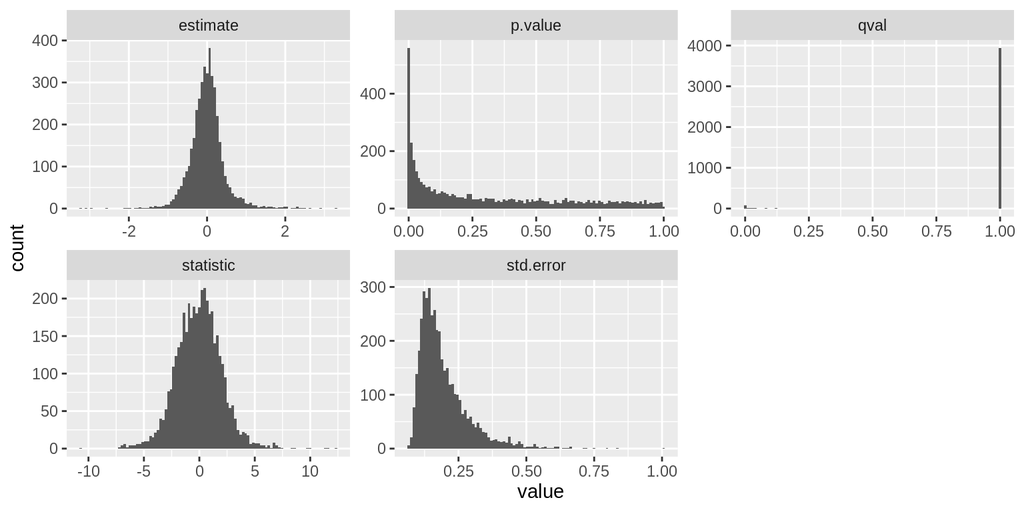

```r
models %>%
  select(-term) %>%
  pivot_longer(cols = where(is.numeric)) %>%
  ggplot(., aes(value))+
  geom_histogram(bins = 100)+
  facet_wrap(~name, scales = "free", ncol = 3)
```

### Panel A

Example models of a growth dependent and growth independent gene

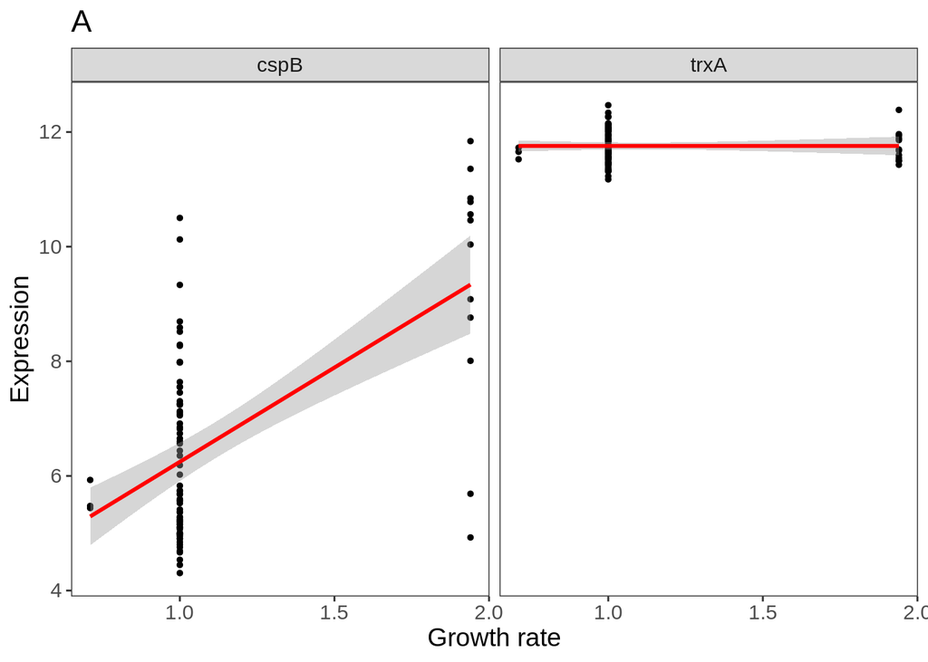

```r
genes.ordered.by.abs.estimate <- models %>%
  arrange(desc(abs(estimate))) %>%
  pull(k12_name)

pa <- rates.expr %>%
  filter(gene == genes.ordered.by.abs.estimate[1] | gene == genes.ordered.by.abs.estimate[length(genes.ordered.by.abs.estimate)]) %>%
  ggplot(., aes(growth_rate_1h, value))+
  geom_point(size = 1)+
  geom_smooth(color = "red", method = "lm")+
  facet_wrap(~gene, ncol = 2)+
  theme_bw()+
  theme(text = element_text(size = 14),
        panel.grid = element_blank())+
  labs(x = "Growth rate",
       y = "Expression",
       title = "A")

pa
```

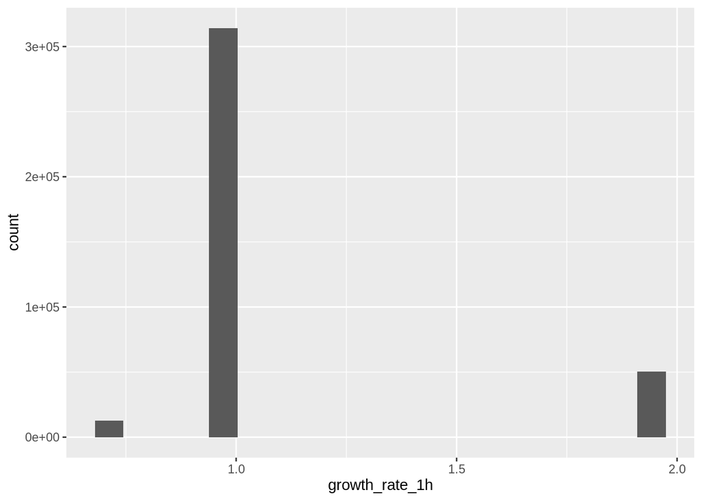

```r
rates.expr %>%
  ggplot(., aes(growth_rate_1h))+
  geom_histogram(bins = 20)
```

### Panel B

Get my fold changes

```r
all.data <- read_csv("../../data_frames/all_data.csv") %>%
  filter(gene_type == "ECB") %>%
  select(line, target_id, k12_name, ds_padj_rna, ds_log2foldchange_rna)
```

How many matches on genes names are there? Join them too.

```r
length(intersect(all.data$k12_name, models$k12_name))
```

```
## [1] 3538
```

```r
joined.df <- left_join(all.data, models, by = "k12_name") %>%
  filter(ds_padj_rna <= .01 & !is.na(estimate)) %>%
  mutate(model_direc = factor(sign(estimate)),
         line = factor(line, mut.levels))
```

KS test the two categories.

```r
ks.results <- joined.df %>%
  split(.$line) %>%
  map(function(x) {
    ks.test(x[x$model_direc == 1, ]$ds_log2foldchange_rna,
            x[x$model_direc == -1, ]$ds_log2foldchange_rna) %>%
      tidy()
  }) %>%
  bind_rows(.id = "line") %>%
  mutate(stars = cut(
    p.value,
    c(1, .05, .01, .001, .0001, -Inf),
    labels = c("****", "***", "**", "*", "NS")
  ))
```

Join the model values to my fold changes

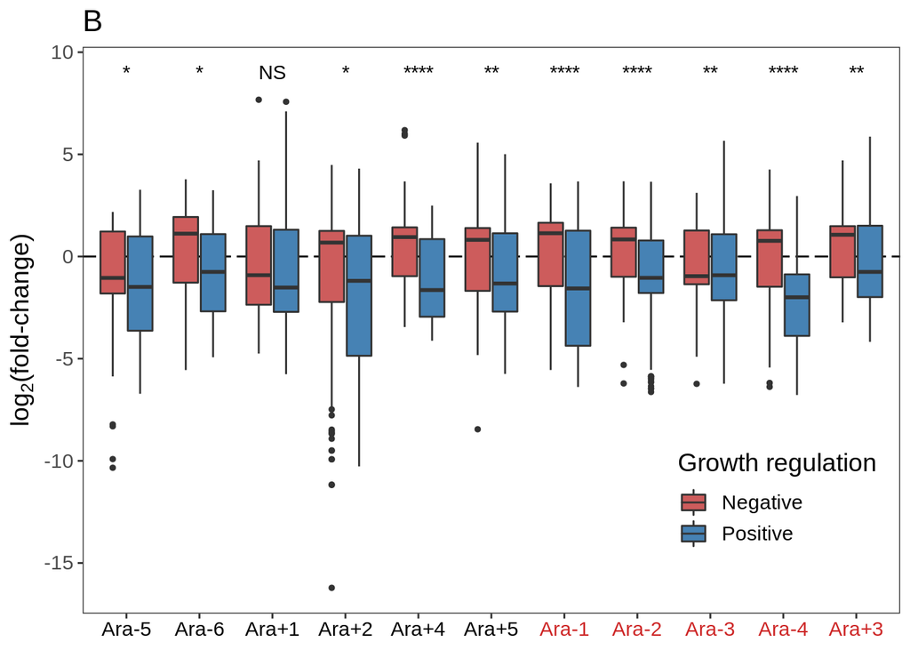

```r
pb <- joined.df %>%
  ggplot(., aes(line, ds_log2foldchange_rna, fill = model_direc))+
  geom_hline(aes(yintercept = 0), linetype = 5)+
  geom_boxplot(outlier.size = 1)+
  theme_bw()+
  theme(panel.grid = element_blank(),
        text = element_text(size = 14),
        axis.text.x = element_text(color = mut.colors),
        legend.position = c(.85, .2),
        legend.background = element_blank())+
  scale_fill_manual(values = c("indianred", "steelblue"), name = "Growth regulation", labels = c("Negative", "Positive"))+
  labs(x = NULL,
       y = expression(paste(log[2], "(fold-change)")),
       title = "B")+
  scale_y_continuous(breaks = seq(-15,10, 5))+
  geom_text(inherit.aes = FALSE, data = ks.results, aes(line, y = 9, label = stars))

pb
```

### Panel C

Correlation between FC and model estimate

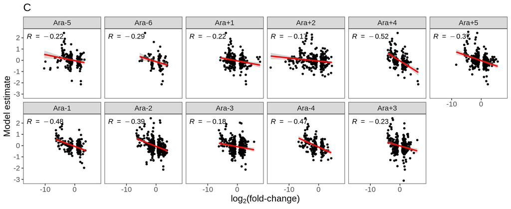

```r
pc <- joined.df %>%
  ggplot(., aes(ds_log2foldchange_rna, estimate))+
  geom_point(size = 1)+
  geom_smooth(color = "red", method = "lm")+
  facet_wrap(~line, ncol = 6)+
  theme_bw()+
  theme(text = element_text(size = 14),
        panel.grid = element_blank())+
  stat_cor(aes(label = ..r.label..))+
  labs(x = expression(paste(log[2], "(fold-change)")),
       y = "Model estimate",
       title = "C")

pc
```

I’m not so sure about the growth rate == 1 values

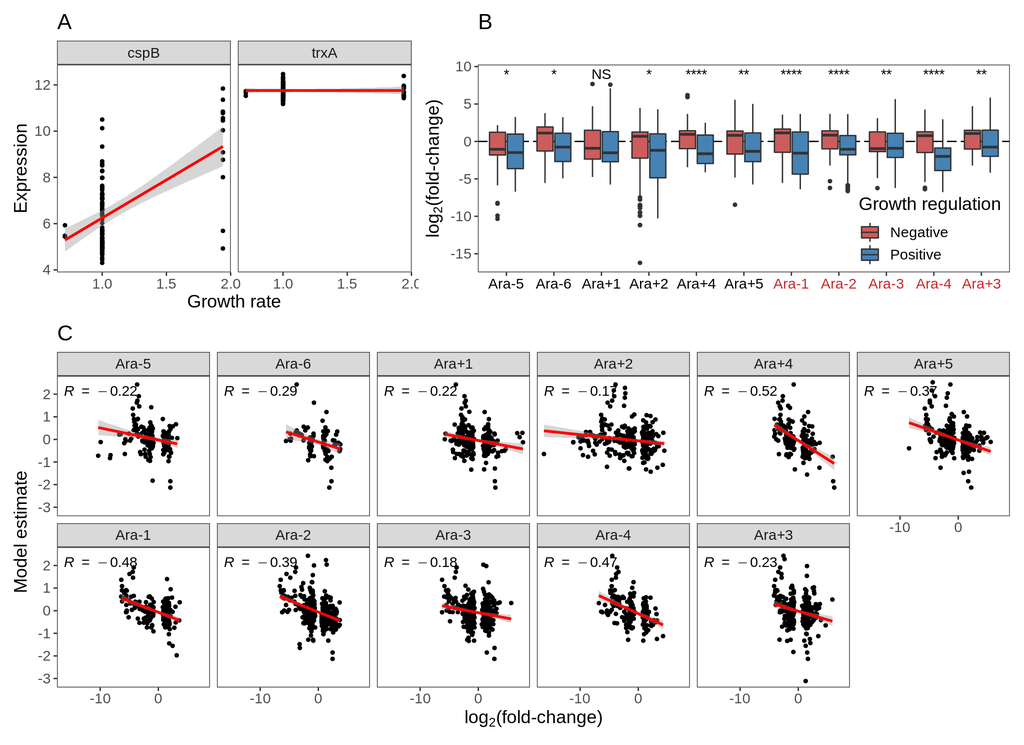

```r
top <- (pa | pb) + plot_layout(widths = c(.4, .6))

(top / pc) + plot_layout(heights = c(.4, .6))
```